# Local Inequality and Support for Right-wing Populism in Britain

Zach Dickson

Department of Methodology  
London School of Economics

2025-06-01

# What Drives Support for Right-Wing Populism?

**Two dominant explanations often compete:**

- **Economic Grievance:** A rebellion of the “left behind,” fueled by globalization, job insecurity, and economic dislocation.
- **Cultural Backlash:** A reaction against progressive values, immigration, and perceived threats to national identity.

# Argument: It’s About Relative Status

- A key mechanism common to both economic and cultural explanations is relative status threat.
- It’s not just about absolute poverty, but the feeling that others around you are getting a better deal.
- Visible, localized inequality can trigger feelings of status loss, resentment, and unfairness.
- **Hypothesis:** *A rise in local inequality, made salient through housing, increases support for populist right parties.*

# Research Design

**Goal: Create a dynamic, small-area measure of wealth inequality**

- **Data & Measurement:**
  - Use detailed housing data to estimate housing prices over time
    - 27 million property transactions in the UK
    - ML model (XGBoost) predicts house values annually
  - Calculate local inequality measures
    - GINI coefficient of house prices annually for each local electoral ward
  - Pair data with attitudinal and electoral data on populist support
    - UKIP/Reform UK vote share in local elections (2006-2021)
    - Individual vote intention from Understanding Society panel study (2008-2023)

# Empirical Strategies

**Three complementary methods to test the hypothesis:**

- **Two-Way Fixed Effects:**
  - Analyzes how changes in inequality within a ward over time affect vote share, controlling for national trends and stable local characteristics.
- **Event Study (Difference-in-Differences):**
  - Treats the construction of a new, high-value property as a “shock” that increases local inequality.
  - Traces the dynamic effect on populist support in the years before and after the shock.
- **Instrumental Variable (Shift-Share):**
  - Uses plausibly random variation from the “Right-to-Buy” policy to isolate the causal effect of inequality from other confounding factors.

## Local Inequality in the UK

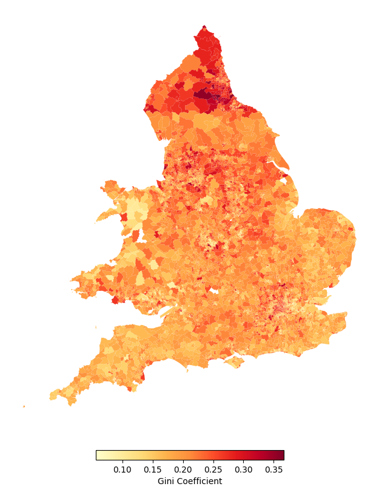

2022 Electoral Ward Inequality

# Key Findings

**Across three research designs and two datasets, a one-standard-deviation increase in local house price inequality is associated with a 2 to 5 percentage point increase in UKIP/Reform UK’s vote share.**

- Two-Way Fixed Effects: **2-3 percentage points** in vote share
- Two-Way Fixed Effects: **2-3 percentage points** in vote intention
- Instrumental Variable (2SLS): **3-5 percentage points** in vote share
- Event Study: **2-4 percentage** points in years 1-2

## The Effect of an Inequality “Shock”

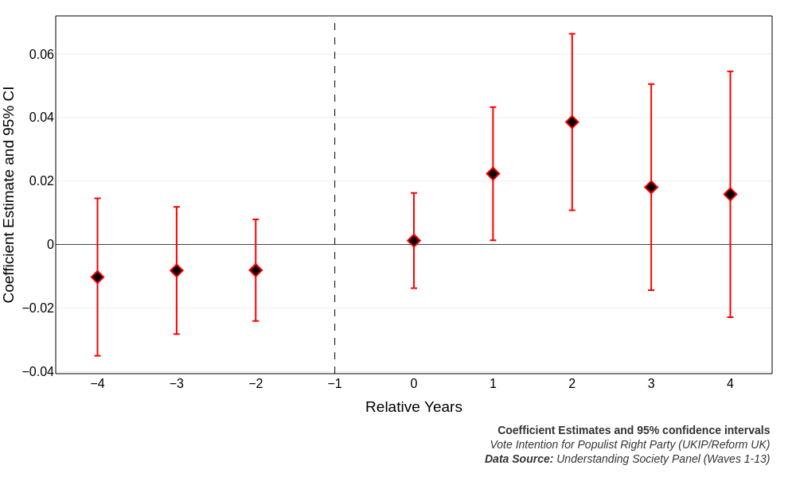

Effects of High-value Properties on Support for Populist Right Party

# Conclusion: Local Status Threat Matters

**Main Takeaway: Salient, localized inequality—made visible through the housing market—is a significant driver of support for the populist right in Britain.**

- Feelings of being “left behind” are often rooted in immediate, local comparisons, not just abstract national statistics
- Relative status threat links both economic and cultural factors to populism.